# Aplicación del algoritmo Naive Bayes al conjunto de datos Iris

Análisis con R

2026-07-06

# 1 Introducción

**Naive Bayes** es un algoritmo de clasificación supervisada basado en el **teorema de Bayes**, que calcula la probabilidad de que una observación pertenezca a una clase, a partir de las probabilidades de sus atributos.

Se llama *“naive”* (ingenuo) porque asume que todos los atributos predictores son **condicionalmente independientes** entre sí dado el valor de la clase. Aunque esta suposición rara vez se cumple exactamente en datos reales, el algoritmo suele funcionar sorprendentemente bien en la práctica, es rápido de entrenar y requiere pocos datos para estimar los parámetros necesarios.

## 1.1 Teorema de Bayes

El teorema de Bayes se expresa como:

$$P(C_k \mid X) = \frac{P(X \mid C_k) \, P(C_k)}{P(X)}$$

Donde:

- $P(C_k \mid X)$: probabilidad posterior de la clase $C_k$ dado el vector de atributos $X$.
- $P(X \mid C_k)$: verosimilitud, probabilidad de observar $X$ dado que la clase es $C_k$.
- $P(C_k)$: probabilidad a priori de la clase $C_k$.
- $P(X)$: probabilidad marginal de $X$ (actúa como constante normalizadora).

Dado el supuesto de independencia condicional, la verosimilitud conjunta se descompone como el producto de las verosimilitudes individuales de cada atributo:

$$P(X \mid C_k) = \prod_{i=1}^{n} P(x_i \mid C_k)$$

El clasificador asigna la observación a la clase que maximiza la probabilidad posterior:

$$\hat{y} = \underset{k}{\operatorname{argmax}} \; P(C_k) \prod_{i=1}^{n}
P(x_i \mid C_k)$$

Cuando los atributos son numéricos continuos (como en el caso de Iris), se suele asumir que, dentro de cada clase, cada atributo sigue una distribución **normal (gaussiana)**, y sus parámetros (media y desviación estándar) se estiman a partir de los datos de entrenamiento.

## 1.2 El conjunto de datos Iris

El dataset **Iris**, recopilado originalmente por Ronald Fisher (1936), contiene 150 observaciones de flores de iris, 50 de cada una de tres especies: *setosa*, *versicolor* y *virginica*. Para cada flor se midieron cuatro atributos numéricos:

- Largo del sépalo (`Sepal.Length`)
- Ancho del sépalo (`Sepal.Width`)
- Largo del pétalo (`Petal.Length`)
- Ancho del pétalo (`Petal.Width`)

El objetivo es predecir la especie (`Species`) a partir de estas cuatro medidas, lo que lo convierte en un problema clásico de clasificación multiclase, ideal para ilustrar Naive Bayes.

# 2 Preparación del entorno

```r
# Instalar paquetes si no están disponibles (ejecutar una sola vez)
paquetes <- c("e1071", "caret", "ggplot2", "GGally")
instalar <- paquetes[!(paquetes %in% installed.packages()[, "Package"])]
if (length(instalar) > 0) install.packages(instalar)

library(e1071)   # Implementación de Naive Bayes
library(caret)   # División de datos y matriz de confusión
library(ggplot2) # Visualización
library(GGally)  # Gráfico de pares de variables
```

# 3 Exploración de los datos

```r
data(iris)
str(iris)
```

```
## 'data.frame':    150 obs. of  5 variables:
##  $ Sepal.Length: num  5.1 4.9 4.7 4.6 5 5.4 4.6 5 4.4 4.9 ...
##  $ Sepal.Width : num  3.5 3 3.2 3.1 3.6 3.9 3.4 3.4 2.9 3.1 ...
##  $ Petal.Length: num  1.4 1.4 1.3 1.5 1.4 1.7 1.4 1.5 1.4 1.5 ...
##  $ Petal.Width : num  0.2 0.2 0.2 0.2 0.2 0.4 0.3 0.2 0.2 0.1 ...
##  $ Species     : Factor w/ 3 levels "setosa","versicolor",..: 1 1 1 1 1 1 1 1 1 1 ...
```

```r
summary(iris)
```

```
##   Sepal.Length    Sepal.Width     Petal.Length    Petal.Width
##  Min.   :4.300   Min.   :2.000   Min.   :1.000   Min.   :0.100
##  1st Qu.:5.100   1st Qu.:2.800   1st Qu.:1.600   1st Qu.:0.300
##  Median :5.800   Median :3.000   Median :4.350   Median :1.300
##  Mean   :5.843   Mean   :3.057   Mean   :3.758   Mean   :1.199
##  3rd Qu.:6.400   3rd Qu.:3.300   3rd Qu.:5.100   3rd Qu.:1.800
##  Max.   :7.900   Max.   :4.400   Max.   :6.900   Max.   :2.500
##        Species
##  setosa    :50
##  versicolor:50
##  virginica :50
##
##
##
```

```r
table(iris$Species)
```

```
##
##     setosa versicolor  virginica
##         50         50         50
```

Las clases están perfectamente balanceadas: 50 observaciones por especie.

## 3.1 Relación entre atributos

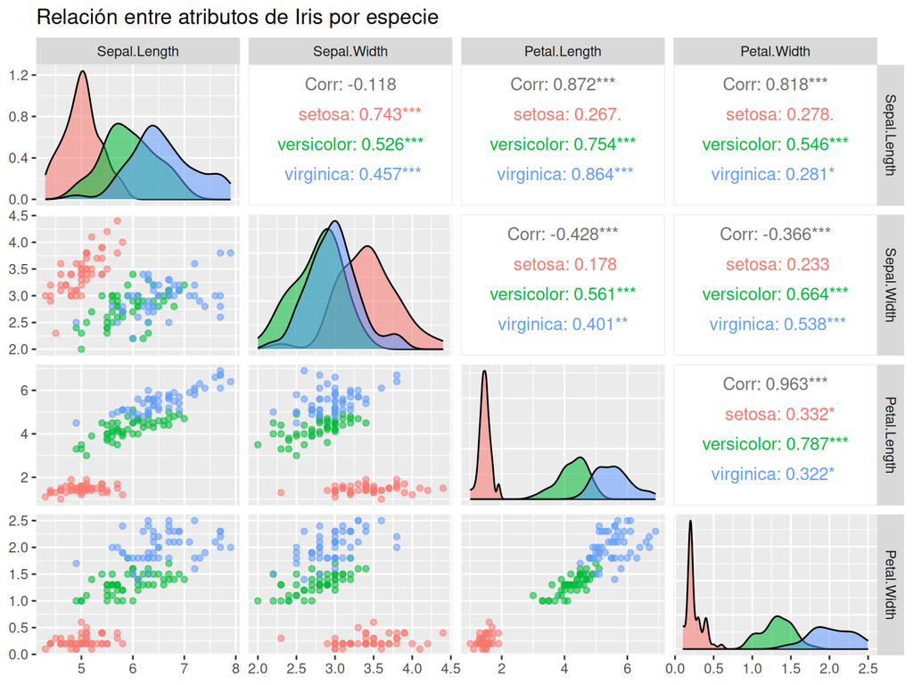

```r
ggpairs(iris, aes(color = Species, alpha = 0.6),
        columns = 1:4,
        title = "Relación entre atributos de Iris por especie")
```

Se observa que `Petal.Length` y `Petal.Width` separan muy bien a *setosa* del resto, mientras que *versicolor* y *virginica* presentan cierto solapamiento.

# 4 División en conjunto de entrenamiento y prueba

Para evaluar el modelo de forma honesta, se separan los datos en un conjunto de entrenamiento (70%) y uno de prueba (30%), manteniendo la proporción de clases mediante muestreo estratificado.

```r
set.seed(123)
indices <- createDataPartition(iris$Species, p = 0.7, list = FALSE)

entrenamiento <- iris[indices, ]
prueba        <- iris[-indices, ]

nrow(entrenamiento)
```

```
## [1] 105
```

```r
nrow(prueba)
```

```
## [1] 45
```

# 5 Entrenamiento del modelo Naive Bayes

Se utiliza la función `naiveBayes()` del paquete `e1071`, que para atributos numéricos estima automáticamente una distribución normal por clase.

```r
modelo_nb <- naiveBayes(Species ~ ., data = entrenamiento)
modelo_nb
```

```
##
## Naive Bayes Classifier for Discrete Predictors
##
## Call:
## naiveBayes.default(x = X, y = Y, laplace = laplace)
##
## A-priori probabilities:
## Y
##     setosa versicolor  virginica
##  0.3333333  0.3333333  0.3333333
##
## Conditional probabilities:
##             Sepal.Length
## Y                [,1]      [,2]
##   setosa     4.991429 0.3657156
##   versicolor 5.942857 0.4558674
##   virginica  6.631429 0.6846087
##
##             Sepal.Width
## Y                [,1]      [,2]
##   setosa     3.365714 0.3455114
##   versicolor 2.777143 0.3227508
##   virginica  2.982857 0.3222035
##
##             Petal.Length
## Y                [,1]      [,2]
##   setosa     1.471429 0.1808012
##   versicolor 4.262857 0.4222389
##   virginica  5.591429 0.5741344
##
##             Petal.Width
## Y                 [,1]       [,2]
##   setosa     0.2314286 0.09321521
##   versicolor 1.3285714 0.20518489
##   virginica  2.0342857 0.25775371
```

La salida del modelo muestra:

- Las probabilidades **a priori** de cada clase (`A-priori probabilities`).
- Para cada atributo y cada clase, la **media** y la **desviación estándar** estimadas, que definen la distribución normal usada para calcular la verosimilitud.

# 6 Predicción sobre el conjunto de prueba

```r
predicciones <- predict(modelo_nb, newdata = prueba)
head(data.frame(Real = prueba$Species, Predicho = predicciones), 10)
```

```
##      Real Predicho
## 1  setosa   setosa
## 2  setosa   setosa
## 3  setosa   setosa
## 4  setosa   setosa
## 5  setosa   setosa
## 6  setosa   setosa
## 7  setosa   setosa
## 8  setosa   setosa
## 9  setosa   setosa
## 10 setosa   setosa
```

También se pueden obtener las probabilidades posteriores para cada clase:

```r
probabilidades <- predict(modelo_nb, newdata = prueba, type = "raw")
head(round(probabilidades, 4))
```

```
##      setosa versicolor virginica
## [1,]      1          0         0
## [2,]      1          0         0
## [3,]      1          0         0
## [4,]      1          0         0
## [5,]      1          0         0
## [6,]      1          0         0
```

# 7 Evaluación del modelo

## 7.1 Matriz de confusión

```r
matriz_confusion <- confusionMatrix(predicciones, prueba$Species)
matriz_confusion
```

```
## Confusion Matrix and Statistics
##
##             Reference
## Prediction   setosa versicolor virginica
##   setosa         15          0         0
##   versicolor      0         13         2
##   virginica       0          2        13
##
## Overall Statistics
##
##                Accuracy : 0.9111
##                  95% CI : (0.7878, 0.9752)
##     No Information Rate : 0.3333
##     P-Value [Acc > NIR] : 8.467e-16
##
##                   Kappa : 0.8667
##
##  Mcnemar's Test P-Value : NA
##
## Statistics by Class:
##
##                      Class: setosa Class: versicolor Class: virginica
## Sensitivity                 1.0000            0.8667           0.8667
## Specificity                 1.0000            0.9333           0.9333
## Pos Pred Value              1.0000            0.8667           0.8667
## Neg Pred Value              1.0000            0.9333           0.9333
## Prevalence                  0.3333            0.3333           0.3333
## Detection Rate              0.3333            0.2889           0.2889
## Detection Prevalence        0.3333            0.3333           0.3333
## Balanced Accuracy           1.0000            0.9000           0.9000
```

## 7.2 Interpretación de resultados

```r
exactitud <- matriz_confusion$overall["Accuracy"]
cat("Exactitud (Accuracy) del modelo:", round(exactitud * 100, 2), "%\n")
```

```
## Exactitud (Accuracy) del modelo: 91.11 %
```

```r
matriz_confusion$byClass[, c("Sensitivity", "Specificity", "Pos Pred Value")]
```

```
##                   Sensitivity Specificity Pos Pred Value
## Class: setosa       1.0000000   1.0000000      1.0000000
## Class: versicolor   0.8666667   0.9333333      0.8666667
## Class: virginica    0.8666667   0.9333333      0.8666667
```

En general, el modelo Naive Bayes clasifica correctamente a *Iris-setosa* con un 100% de precisión, dado que es linealmente separable de las otras dos especies. Los eventuales errores de clasificación suelen concentrarse entre *versicolor* y *virginica*, ya que estas dos clases presentan atributos con distribuciones más solapadas (especialmente en `Sepal.Width` y `Sepal.Length`).

# 8 Visualización de la frontera de decisión (Petal.Length vs Petal.Width)

Para ilustrar visualmente cómo separa el modelo a las clases, se entrena un segundo modelo usando solo dos atributos (los más discriminantes) y se grafica la región de decisión.

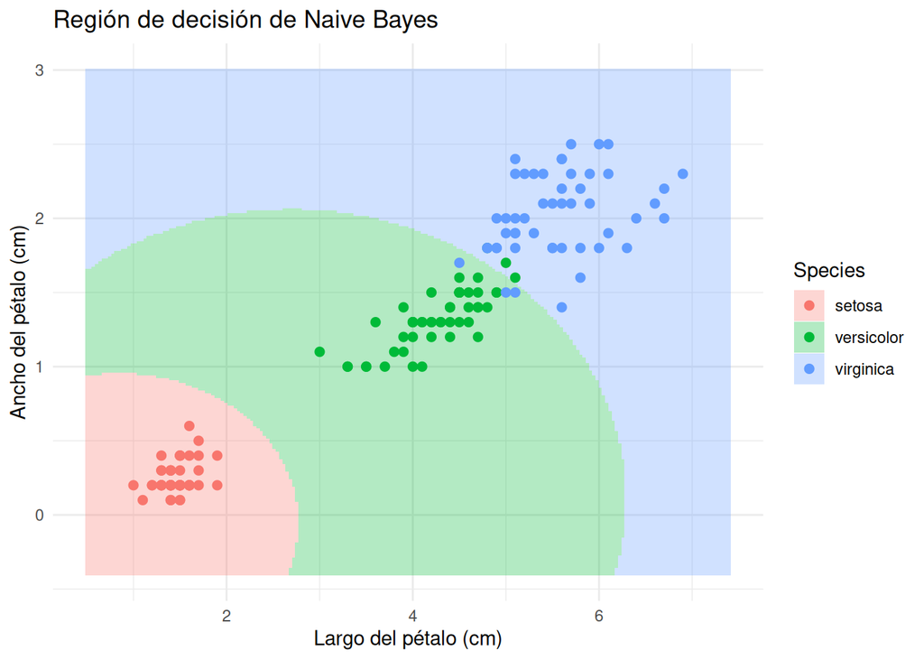

```r
modelo_2d <- naiveBayes(Species ~ Petal.Length + Petal.Width, data = entrenamiento)

rango_largo <- seq(min(iris$Petal.Length) - 0.5, max(iris$Petal.Length) + 0.5, length.out = 200)
rango_ancho <- seq(min(iris$Petal.Width) - 0.5, max(iris$Petal.Width) + 0.5, length.out = 200)
malla <- expand.grid(Petal.Length = rango_largo, Petal.Width = rango_ancho)
malla$Species <- predict(modelo_2d, newdata = malla)

ggplot() +
  geom_tile(data = malla, aes(x = Petal.Length, y = Petal.Width, fill = Species), alpha = 0.3) +
  geom_point(data = iris, aes(x = Petal.Length, y = Petal.Width, color = Species), size = 2) +
  labs(title = "Región de decisión de Naive Bayes",
       x = "Largo del pétalo (cm)", y = "Ancho del pétalo (cm)") +
  theme_minimal()
```

# 9 Ventajas y limitaciones observadas

**Ventajas:**

- Entrenamiento muy rápido y de bajo costo computacional.
- Buen desempeño incluso con pocos datos.
- Fácil de interpretar: cada clase queda descrita por medias y desviaciones estándar de sus atributos.

**Limitaciones:**

- El supuesto de independencia entre atributos rara vez se cumple (por ejemplo, `Petal.Length` y `Petal.Width` están altamente correlacionados).
- Al asumir distribuciones normales para atributos continuos, el modelo puede perder precisión si esa suposición no se ajusta bien a los datos reales.
- Su desempeño se degrada frente a clases con distribuciones muy solapadas, como se observó entre *versicolor* y *virginica*.

# 10 Conclusión

A pesar de su simplicidad y de la suposición “ingenua” de independencia entre atributos, Naive Bayes logra un desempeño alto en el conjunto de datos Iris, en gran parte porque una de las tres clases (*setosa*) es linealmente separable y las variables de pétalo son muy informativas. Esto confirma que Naive Bayes es una excelente opción como modelo base (*baseline*) rápido y sencillo antes de probar algoritmos más complejos.